# Practical Machine Learning Course Project

Shashank Nigam

## Introduction:

The project is to correctly classify the data received the class of the barbell lifts from the data obtained from the belt,forearm,arm and dumbell of 6 participants in 5 different ways: exactly according to the specification(class A), throwing the elbows to the front(Class B),lifting the dumbell only halfway(Class C),lowering dumbell only half way(Class D) and throwing the hips to the forward(Class E).

1. Reading Data

```r
data<-data<-read.csv("PMLTraining.csv")
dim(data)
```

```
## [1] 19622   160
```

```r
summary(data)
```

```
##        X            user_name    raw_timestamp_part_1 raw_timestamp_part_2
##  Min.   :    1   adelmo  :3892   Min.   :1.322e+09    Min.   :   294
##  1st Qu.: 4906   carlitos:3112   1st Qu.:1.323e+09    1st Qu.:252912
##  Median : 9812   charles :3536   Median :1.323e+09    Median :496380
##  Mean   : 9812   eurico  :3070   Mean   :1.323e+09    Mean   :500656
##  3rd Qu.:14717   jeremy  :3402   3rd Qu.:1.323e+09    3rd Qu.:751891
##  Max.   :19622   pedro   :2610   Max.   :1.323e+09    Max.   :998801
##
##           cvtd_timestamp  new_window    num_window      roll_belt
##  28/11/2011 14:14: 1498   no :19216   Min.   :  1.0   Min.   :-28.90
##  05/12/2011 11:24: 1497   yes:  406   1st Qu.:222.0   1st Qu.:  1.10
##  30/11/2011 17:11: 1440               Median :424.0   Median :113.00
##  05/12/2011 11:25: 1425               Mean   :430.6   Mean   : 64.41
##  02/12/2011 14:57: 1380               3rd Qu.:644.0   3rd Qu.:123.00
##  02/12/2011 13:34: 1375               Max.   :864.0   Max.   :162.00
##  (Other)         :11007
##    pitch_belt          yaw_belt       total_accel_belt kurtosis_roll_belt
##  Min.   :-55.8000   Min.   :-180.00   Min.   : 0.00             :19216
##  1st Qu.:  1.7600   1st Qu.: -88.30   1st Qu.: 3.00    #DIV/0!  :   10
##  Median :  5.2800   Median : -13.00   Median :17.00    -1.908453:    2
##  Mean   :  0.3053   Mean   : -11.21   Mean   :11.31    -0.016850:    1
##  3rd Qu.: 14.9000   3rd Qu.:  12.90   3rd Qu.:18.00    -0.021024:    1
##  Max.   : 60.3000   Max.   : 179.00   Max.   :29.00    -0.025513:    1
##                                                        (Other)  :  391
##  kurtosis_picth_belt kurtosis_yaw_belt skewness_roll_belt
##           :19216            :19216              :19216
##  #DIV/0!  :   32     #DIV/0!:  406     #DIV/0!  :    9
##  47.000000:    4                       0.000000 :    4
##  -0.150950:    3                       0.422463 :    2
##  -0.684748:    3                       -0.003095:    1
##  -1.750749:    3                       -0.010002:    1
##  (Other)  :  361                       (Other)  :  389
##  skewness_roll_belt.1 skewness_yaw_belt max_roll_belt     max_picth_belt
##           :19216             :19216     Min.   :-94.300   Min.   : 3.00
##  #DIV/0!  :   32      #DIV/0!:  406     1st Qu.:-88.000   1st Qu.: 5.00
##  0.000000 :    4                        Median : -5.100   Median :18.00
##  -2.156553:    3                        Mean   : -6.667   Mean   :12.92
##  -3.072669:    3                        3rd Qu.: 18.500   3rd Qu.:19.00
##  -6.324555:    3                        Max.   :180.000   Max.   :30.00
##  (Other)  :  361                        NA's   :19216     NA's   :19216
```

[output cut: 313 more lines]

```
##  Min.   :-446.00   Min.   :-1280.0   Min.   :-896.0   Min.   :-973.0
##  1st Qu.:-182.00   1st Qu.: -616.0   1st Qu.:   2.0   1st Qu.: 191.0
##  Median : -39.00   Median : -378.0   Median : 591.0   Median : 511.0
##  Mean   : -55.29   Mean   : -312.6   Mean   : 380.1   Mean   : 393.6
##  3rd Qu.:  26.00   3rd Qu.:  -73.0   3rd Qu.: 737.0   3rd Qu.: 653.0
##  Max.   : 291.00   Max.   :  672.0   Max.   :1480.0   Max.   :1090.0
##
##  classe
##  A:5580
##  B:3797
##  C:3422
##  D:3216
##  E:3607
##
##
```

As seen from the data set it can be seen that the data contains missing or null values for the whose names starts with max,min,std,avg,std,skewness,kurtosis. Cleaning data to remove the variables not required from the datasets

```r
num<-c(grep(c("max*"),names(data)),grep("kurtosis*",names(data)),grep("skewness*",names(data)),grep("min*",names(data)),grep("amplitude*",names(data)),grep("var*",names(data)),grep("avg*",names(data)),grep("std*",names(data)))
data<-data[,-num]
dim(data)
```

```
## [1] 19622    45
```

### Analysing the Data:

The relation of the data with the class variable can be studied using the following plots. The variables taken for analysis are total acceleration of beelt arm dumbell and forearm:

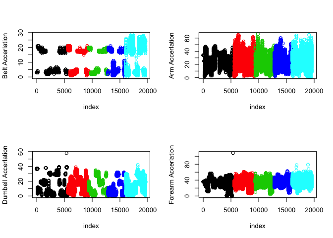

```r
par(mfrow=c(2,2))
plot(data$total_accel_belt,col=data$classe,xlab="index",ylab="Belt Accerlation")
plot(data$total_accel_arm,col=data$classe,xlab="index",ylab="Arm Accerlation")
plot(data$total_accel_dumbbell,col=data$classe,xlab="index",ylab="Dumbell Accerlation")
plot(data$total_accel_forearm,col=data$classe,xlab="index",ylab="Forearm Accerlation")
```

As seen the data seems to be uniformly distributed accross all classes and there appears no specific linear correlation of the data with classes.

### Applying Subsampling:

The model is build using the bootstraping method for subsampling. The bootstraping without replacement is used to create a training and a test set on a probability of 75%.For reproducibility the seed is set to 1234

```r
set.seed(1234)
library(caret)
inTrain<-createDataPartition(data$classe,p=0.75,list=FALSE)
training<-data[inTrain,]
testing<-data[-inTrain,]
```

For the cross validation repeated cross validation is used on the traing data is considered with 10 repeats and 10 folds.

```r
crl<-trainControl(method="repeatedcv",number=10,repeats=10)
```